# Homework Assignment 1

### Q4

**4. Which manufacturers fly the greatest and least distances?** To learn which manufacturers fly the greatest and least distances, I first created a sum of distance traveled grouped by manufacturer. Then, in exploring this data, I can see that Boeing has flown the greatest distance by far (129780208 miles), followed by Airbus (67644103 miles), and then Airbus Industrie (40117602 miles). On the other side of the spectrum, Avions Marcel Dassault flew the fewest miles (2176 miles). This data could be important for carriers who are looking to strike deals with manufacturers, employees deciding where to work, or strategy teams in deciding where to focus aviation investments.

```r
summary(merged$manufacturer)
```

```
##                    AGUSTA SPA                        AIRBUS
##                            32                         47302
##              AIRBUS INDUSTRIE         AMERICAN AIRCRAFT INC
##                         40891                            42
##            AVIAT AIRCRAFT INC        AVIONS MARCEL DASSAULT
##                            18                             4
##                 BARKER JACK L                         BEECH
##                           252                            47
##                          BELL                        BOEING
##                            65                         82912
##                BOMBARDIER INC                      CANADAIR
##                         28272                          1594
##                  CANADAIR LTD                        CESSNA
##                           103                           658
##            CIRRUS DESIGN CORP                   DEHAVILLAND
##                           291                            63
##                       DOUGLAS                       EMBRAER
##                            22                         66068
##                FRIEDEMANN JON          GULFSTREAM AEROSPACE
##                            63                           499
##            HURLEY JAMES LARRY                   JOHN G HESS
##                            17                             3
##                  KILDALL GARY               LAMBERT RICHARD
##                            51                            54
##                   LEARJET INC               LEBLANC GLENN T
##                            19                            40
##                    MARZ BARRY             MCDONNELL DOUGLAS
##                            44                          3998
## MCDONNELL DOUGLAS AIRCRAFT CO MCDONNELL DOUGLAS CORPORATION
##                          8932                          1259
##                   PAIR MIKE E                         PIPER
##                            25                           162
##        ROBINSON HELICOPTER CO                      SIKORSKY
##                           286                            27
##                  STEWART MACO
##                            55
```

```r
sumDistbyManufacturer <- tapply(merged$distance, merged$manufacturer, sum, na.rm=TRUE)
sumDistbyManufacturer<- round(sumDistbyManufacturer[order(sumDistbyManufacturer, decreasing=TRUE)], 2)
sumDistbyManufacturer
```

```
##                        BOEING                        AIRBUS
##                     129780208                      67644103
##              AIRBUS INDUSTRIE                       EMBRAER
##                      40117602                      34604019
##                BOMBARDIER INC MCDONNELL DOUGLAS AIRCRAFT CO
##                      14990924                       8156412
##             MCDONNELL DOUGLAS MCDONNELL DOUGLAS CORPORATION
##                       3841569                       1141928
##                        CESSNA            CIRRUS DESIGN CORP
##                        552090                        378957
##                      CANADAIR        ROBINSON HELICOPTER CO
##                        364270                        361089
##                 BARKER JACK L          GULFSTREAM AEROSPACE
##                        337689                        284139
##                         PIPER                          BELL
##                        193113                         94160
##                         BEECH                  STEWART MACO
##                         77216                         72682
##                FRIEDEMANN JON                   DEHAVILLAND
##                         61165                         58817
##                    AGUSTA SPA                   PAIR MIKE E
##                         55806                         54031
##               LAMBERT RICHARD                  KILDALL GARY
##                         53237                         48637
##                      SIKORSKY                       DOUGLAS
##                         47569                         44776
##                    MARZ BARRY         AMERICAN AIRCRAFT INC
##                         44026                         42199
##                   LEARJET INC               LEBLANC GLENN T
##                         41649                         38143
##                  CANADAIR LTD            AVIAT AIRCRAFT INC
##                         37287                         35929
##            HURLEY JAMES LARRY                   JOHN G HESS
##                         18401                          2286
##        AVIONS MARCEL DASSAULT
##                          2176
```

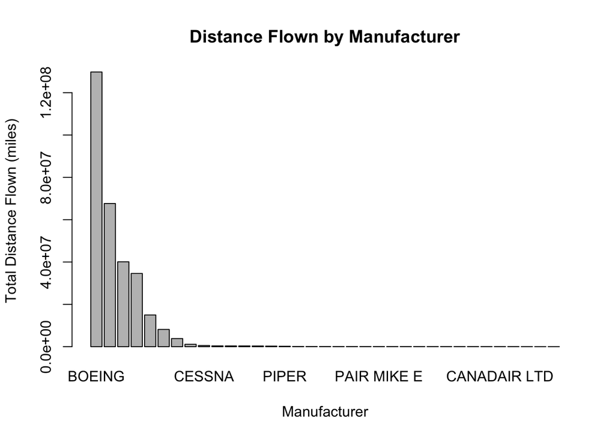

```r
barplot(sumDistbyManufacturer, xlab = "Manufacturer", ylab="Total Distance Flown (miles)", main = "Distance Flown by Manufacturer")
```

```r
head(sumDistbyManufacturer)
```

```
##                        BOEING                        AIRBUS
##                     129780208                      67644103
##              AIRBUS INDUSTRIE                       EMBRAER
##                      40117602                      34604019
##                BOMBARDIER INC MCDONNELL DOUGLAS AIRCRAFT CO
##                      14990924                       8156412
```

```r
tail(sumDistbyManufacturer)
```

```
##        LEBLANC GLENN T           CANADAIR LTD     AVIAT AIRCRAFT INC
##                  38143                  37287                  35929
##     HURLEY JAMES LARRY            JOHN G HESS AVIONS MARCEL DASSAULT
##                  18401                   2286                   2176
```

### Q5

**5. Which manufacturers do the biggest carriers use?** First, I identified the biggest carriers (as those with most flights) to be UA, EV, B6, and DL, in that order. Then, I examined which manufacturers those airlines used. I found that Boeing is the most frequently used manufacturer across the biggest carriers. Conversely, McDonnel Douglas is used by the biggest carriers, but is used the least frequently (141 flights). This could have business implications for carriers and manufacturers alike.

```r
summary(merged$carrier)
```

```
##    9E    AA    AS    B6    DL    EV    F9    FL    HA    MQ    OO    UA    US
## 17416 10171   714 53805 48000 54173   635  3073   342  1000    32 56972 19837
##    VX    WN    YV
##  5162 12237   601
```

```r
bigcarriers <- merged[merged$carrier=='UA' | merged$carrier=='EV' | merged$carrier=='B6' | merged$carrier=='DL', ]
summary(bigcarriers)
```

```
##     tailnum           year.x         month             day
##  N258JB :   427   Min.   :2013   8      : 18782   Min.   : 1.00
##  N298JB :   407   1st Qu.:2013   7      : 18698   1st Qu.: 8.00
##  N353JB :   404   Median :2013   3      : 18407   Median :16.00
##  N351JB :   402   Mean   :2013   10     : 18286   Mean   :15.74
##  N228JB :   388   3rd Qu.:2013   5      : 18195   3rd Qu.:23.00
##  N274JB :   370   Max.   :2013   4      : 17983   Max.   :31.00
##  (Other):210552                  (Other):102599
##     dep_time    sched_dep_time   dep_delay         arr_time    sched_arr_time
##  Min.   :   1   Min.   : 500   Min.   :-43.00   Min.   :   1   Min.   :   1
##  1st Qu.: 902   1st Qu.: 900   1st Qu.: -5.00   1st Qu.:1057   1st Qu.:1120
##  Median :1408   Median :1400   Median : -1.00   Median :1528   Median :1555
##  Mean   :1357   Mean   :1352   Mean   : 13.63   Mean   :1492   Mean   :1534
##  3rd Qu.:1757   3rd Qu.:1735   3rd Qu.: 12.00   3rd Qu.:1946   3rd Qu.:1953
##  Max.   :2400   Max.   :2359   Max.   :960.00   Max.   :2400   Max.   :2359
##  NA's   :3625                  NA's   :3625     NA's   :3838
##    arr_delay          carrier          flight       origin
##  Min.   :-75.000   UA     :56972   15     :   717   EWR:99787
##  1st Qu.:-17.000   EV     :54173   1109   :   714   JFK:67795
##  Median : -5.000   B6     :53805   703    :   652   LGA:45368
##  Mean   :  7.621   DL     :48000   83     :   615
##  3rd Qu.: 15.000   9E     :    0   301    :   576
##  Max.   :931.000   AA     :    0   1643   :   571
##  NA's   :4286      (Other):    0   (Other):209105
##       dest           air_time        distance         hour
##  MCO    : 13147   Min.   : 20.0   Min.   :  80   Min.   : 5.00
##  ATL    : 12364   1st Qu.: 91.0   1st Qu.: 541   1st Qu.: 9.00
##  FLL    : 11680   Median :139.0   Median : 963   Median :14.00
##  LAX    :  9758   Mean   :157.5   Mean   :1099   Mean   :13.26
##  SFO    :  9361   3rd Qu.:198.0   3rd Qu.:1416   3rd Qu.:17.00
##  BOS    :  8796   Max.   :695.0   Max.   :4963   Max.   :23.00
##  (Other):147844   NA's   :4286
##      minute       time_hour            airGain            year.y
##  Min.   : 0.00   Length:212950      Min.   :-161.00   2001   : 22418
##  1st Qu.: 9.00   Class :character   1st Qu.:  -3.00   2002   : 21311
##  Median :29.00   Mode  :character   Median :   8.00   1999   : 16154
##  Mean   :26.74                      Mean   :   5.93   1998   : 16058
##  3rd Qu.:44.00                      3rd Qu.:  17.00   2000   : 15287
##  Max.   :59.00                      Max.   : 109.00   (Other):117862
##                                     NA's   :4286      NA's   :  3860
```

[output cut: 9 more lines]

```
##  Length:212950      Min.   :1.000   Min.   :  2.0   Min.   :432
##  Class :character   1st Qu.:2.000   1st Qu.: 55.0   1st Qu.:432
##  Mode  :character   Median :2.000   Median :149.0   Median :432
##                     Mean   :1.996   Mean   :134.4   Mean   :432
##                     3rd Qu.:2.000   3rd Qu.:191.0   3rd Qu.:432
##                     Max.   :4.000   Max.   :450.0   Max.   :432
##                                                     NA's   :212859
##            engine           flightTime
##  4 Cycle      :     0   afternoon:51066
##  Reciprocating:   543   evening  :54540
##  Turbo-fan    :173803   morning  :83543
##  Turbo-jet    : 38318   night    :23801
##  Turbo-prop   :     0
##  Turbo-shaft  :   286
##
```

```r
summary(bigcarriers$manufacturer)
```

```
##                    AGUSTA SPA                        AIRBUS
##                             0                         36422
##              AIRBUS INDUSTRIE         AMERICAN AIRCRAFT INC
##                         30776                             0
##            AVIAT AIRCRAFT INC        AVIONS MARCEL DASSAULT
##                             0                             0
##                 BARKER JACK L                         BEECH
##                           252                             0
##                          BELL                        BOEING
##                             0                         61558
##                BOMBARDIER INC                      CANADAIR
##                         10227                          1594
##                  CANADAIR LTD                        CESSNA
##                             0                             0
##            CIRRUS DESIGN CORP                   DEHAVILLAND
##                           291                             0
##                       DOUGLAS                       EMBRAER
##                             0                         61212
##                FRIEDEMANN JON          GULFSTREAM AEROSPACE
##                             0                             0
##            HURLEY JAMES LARRY                   JOHN G HESS
##                             0                             0
##                  KILDALL GARY               LAMBERT RICHARD
##                             0                             0
##                   LEARJET INC               LEBLANC GLENN T
##                             0                             0
##                    MARZ BARRY             MCDONNELL DOUGLAS
##                             0                           141
## MCDONNELL DOUGLAS AIRCRAFT CO MCDONNELL DOUGLAS CORPORATION
##                          8932                          1259
##                   PAIR MIKE E                         PIPER
##                             0                             0
##        ROBINSON HELICOPTER CO                      SIKORSKY
##                           286                             0
##                  STEWART MACO
##                             0
```

```r
table <- table(bigcarriers$manufacturer)
table
```

```
##
##                    AGUSTA SPA                        AIRBUS
##                             0                         36422
##              AIRBUS INDUSTRIE         AMERICAN AIRCRAFT INC
##                         30776                             0
##            AVIAT AIRCRAFT INC        AVIONS MARCEL DASSAULT
##                             0                             0
##                 BARKER JACK L                         BEECH
##                           252                             0
##                          BELL                        BOEING
##                             0                         61558
##                BOMBARDIER INC                      CANADAIR
##                         10227                          1594
##                  CANADAIR LTD                        CESSNA
##                             0                             0
##            CIRRUS DESIGN CORP                   DEHAVILLAND
##                           291                             0
##                       DOUGLAS                       EMBRAER
##                             0                         61212
##                FRIEDEMANN JON          GULFSTREAM AEROSPACE
##                             0                             0
##            HURLEY JAMES LARRY                   JOHN G HESS
##                             0                             0
##                  KILDALL GARY               LAMBERT RICHARD
##                             0                             0
##                   LEARJET INC               LEBLANC GLENN T
##                             0                             0
##                    MARZ BARRY             MCDONNELL DOUGLAS
##                             0                           141
## MCDONNELL DOUGLAS AIRCRAFT CO MCDONNELL DOUGLAS CORPORATION
##                          8932                          1259
##                   PAIR MIKE E                         PIPER
##                             0                             0
##        ROBINSON HELICOPTER CO                      SIKORSKY
##                           286                             0
##                  STEWART MACO
##                             0
```

```r
max(table)
```

```
## [1] 61558
```

```r
min(table)
```

```
## [1] 0
```